# Homework 0

Ralph Trane

1/21/2020

The following is the product of great collaboration with Nathanial.

First we import packages we will need.

```r
library(tidyverse)
```

We read the data into R.

```r
measles <- read_csv("measles.csv")
```

# Question 1

We have 6 variables in the data set. They are disease, state, year, weeks_reporting, count, and population.

# Question 2

The data have 3876 observations.

# Question 3

Using `filter`, we can get just the data for Wisconsin in 1993.

```r
filter(measles, state == "Wisconsin", year == 1993)
```

```
## # A tibble: 1 x 6
##   disease state      year weeks_reporting count population
##   <chr>   <chr>     <dbl>           <dbl> <dbl>      <dbl>
## 1 Measles Wisconsin  1993               9     0    5013015
```

# Question 4

To find the mean rate by state we first create a new varible called `rate` (using `mutate`), then `group_by` state before summarizing the data. We use `arrange` to find the smallest and largest means.

```r
measles %>%
  mutate(rate = count / population) %>%
  group_by(state) %>%
  summarize(mean = mean(rate)) %>%
  arrange(mean)
```

```
## # A tibble: 51 x 2
##    state           mean
##    <chr>          <dbl>
##  1 Mississippi 0.000249
##  2 Louisiana   0.000341
##  3 Georgia     0.000621
##  4 Oklahoma    0.000651
##  5 Missouri    0.000738
##  6 Nevada      0.000750
##  7 Florida     0.000766
##  8 Nebraska    0.000869
##  9 Alabama     0.000927
## 10 Arkansas    0.000937
## # … with 41 more rows
```

The state with the overall lowest mean rate is Mississippi.

```r
measles %>%
  mutate(rate = count / population) %>%
  group_by(state) %>%
  summarize(mean = mean(rate)) %>%
  arrange(desc(mean))
```

```
## # A tibble: 51 x 2
##    state            mean
##    <chr>           <dbl>
##  1 Wisconsin     0.00444
##  2 Vermont       0.00379
##  3 Utah          0.00343
##  4 Montana       0.00310
##  5 New Jersey    0.00261
##  6 Connecticut   0.00246
##  7 Colorado      0.00244
##  8 Arizona       0.00242
##  9 Michigan      0.00236
## 10 Massachusetts 0.00234
## # … with 41 more rows
```

The state with the overall largest mean rate is Wisconsin.

# Question 5

Data is missing for Alaska and Hawaii, so we remove them. The we create the rate variable, `group_by` year, and summarize to get the mean rate per year. The result is saved to an object called `yearly_mean_rate`.

```r
yearly_mean_rate <- measles %>%
  filter(state != "Alaska", state != "Hawaii") %>%
  mutate(rate = count / population) %>%
  group_by(year) %>%
  summarize(mean = mean(rate))
```

To actually show the result:

```r
yearly_mean_rate
```

```
## # A tibble: 76 x 2
##     year    mean
##    <dbl>   <dbl>
##  1  1928 0.00348
##  2  1929 0.00247
##  3  1930 0.00298
##  4  1931 0.00315
##  5  1932 0.00294
##  6  1933 0.00239
##  7  1934 0.00622
##  8  1935 0.00511
##  9  1936 0.00255
## 10  1937 0.00228
## # … with 66 more rows
```

Create a plot:

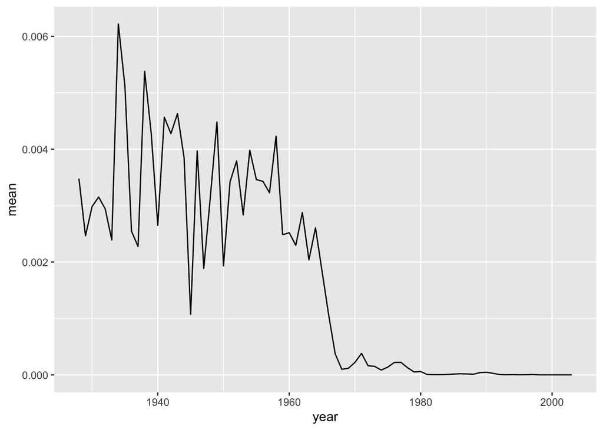

```r
ggplot(data = yearly_mean_rate,
       aes(x = year, y = mean)) +
  geom_line()
```

From the plot, it seems like something significant happened around 1960.

# Question 6

Add a vertical line using `geom_vline`.

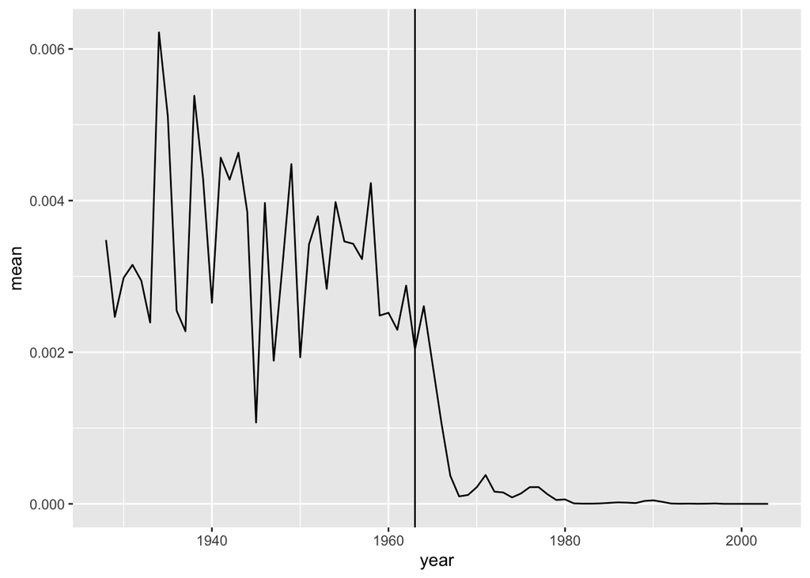

```r
ggplot(data = yearly_mean_rate,
       aes(x = year, y = mean)) +
  geom_line() +
  geom_vline(xintercept = 1963)
```

Just for Wisconsin and Alabama.

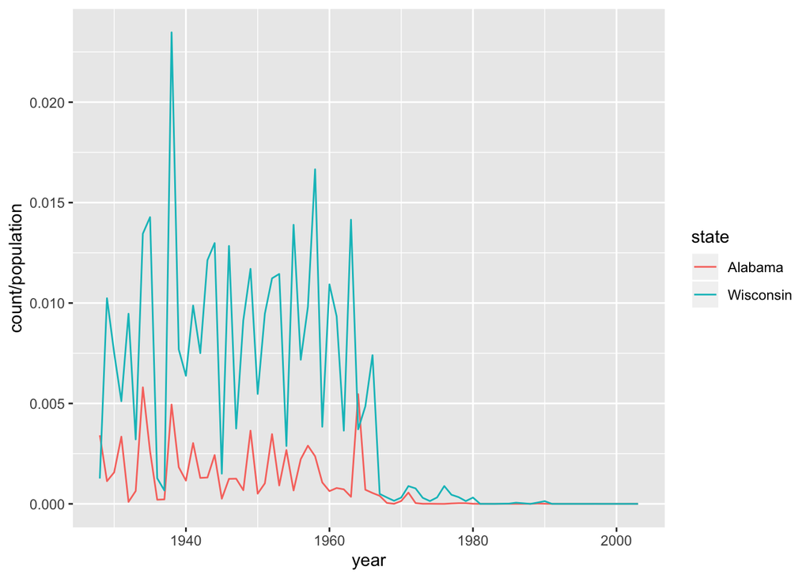

```r
ggplot(data = filter(measles, state %in% c("Wisconsin", "Alabama")),
       aes(x = year, y = count / population, color = state)) +
  geom_line()
```

# Bonus

Pretty plot using `geom_tile`, and make the vertical line red.

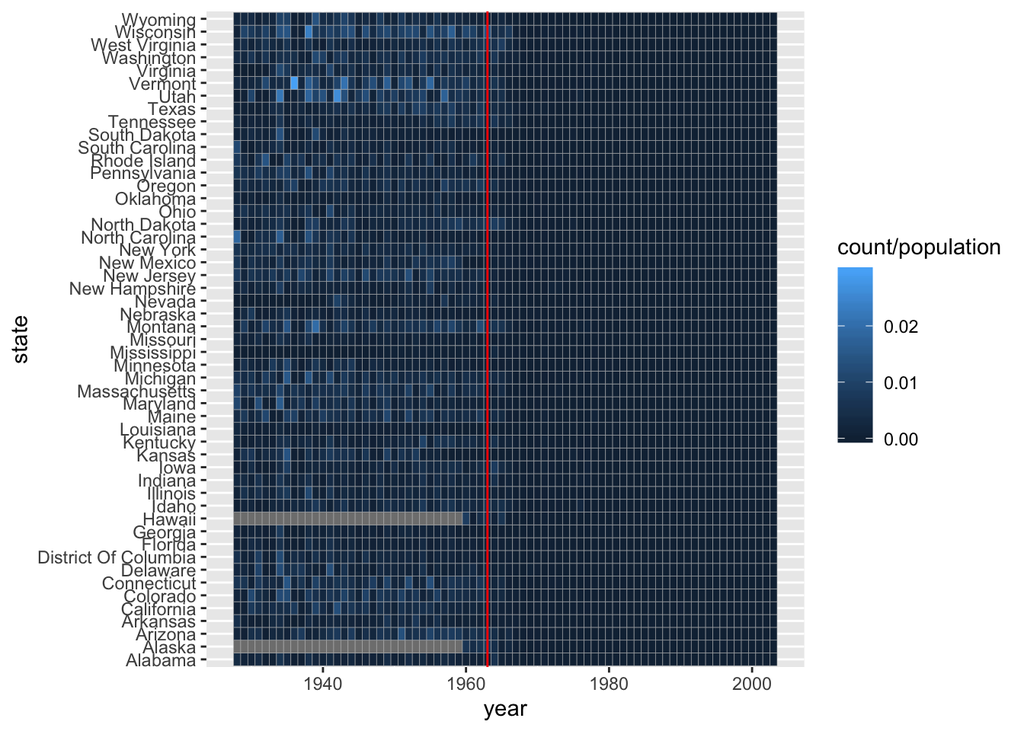

```r
ggplot(data = measles,
       aes(x = year, y = state, fill = count / population)) +
  geom_tile(color = "grey") +
  geom_vline(xintercept = 1963, color = "red")
```